# STAT40710 Time Series Project

Fangyijie Wang

4/20/2022

### Simulate AR + ARCH Model

**1.** If the model is AR(1) + ARCH(1), then $y_t = \phi * y_{t-1} + \eta_t$ (where $\eta_t$ follows an ARCH(1) model)  
**2.** Then $\eta_t = \sigma_t * \epsilon_t$ where $\sigma_t^2 = \omega + \alpha_1 \eta_{t-1}^2 + \beta_1 \sigma^2_{t-1}$  
Load required libraries.

```r
library(TSA)
library(fGarch)
#set.seed(13204942)
```

Firstly, we need to initialize hyperparameters:

```r
u = 1 # AR order
v = 0 # MA order
p = 1 # GARCH order
q = 1 # GARCH order
```

```r
# sampling coefficients
samp_coefs = function(l){
  vec = rep(0,l)
  for(i in 1:l){
    vec[i] = runif(1, 0, 1) * sample(c(-1,1), 1)
  }
  return(vec)
}
```

Setup fixed values of parameters.

```r
mu = 0 # (the linear part) the mean value, by default NULL
omega = 0.1 # the constant coefficient of the variance equation (default 1e-6)
alpha = 0.2
beta = 0.5
phi = 0.6
#alpha;phi

# length of time series
n = 300

# alpha = 0; if (p > 0) alpha = samp_coefs(p) # the values of AR coefficients
# beta = 0; if (q > 0) beta = samp_coefs(q) # the values of variance coefficients
# phi = 0; if (u > 0) phi = samp_coefs(u) # the values of AR coefficients (ARIMA)
```

Simulate the GARCH(1,1) model for $\eta$ with parameters.

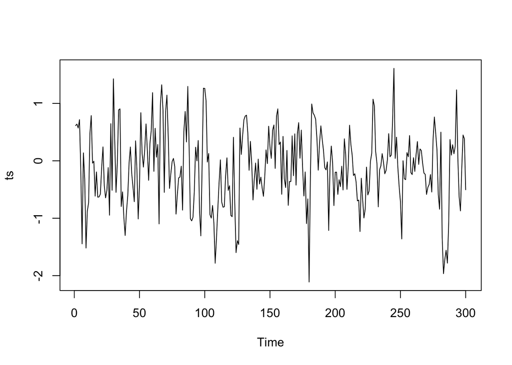

```r
# GARCH(1,1)
spec = garchSpec(model = list(mu = 0, omega = omega, alpha = alpha, beta = beta))
#spec = garchSpec(model = list(mu = 0, omega = 0.01, alpha = 0.5, beta = beta))
eta = garchSim(spec, n)
# use simulated eta to simulate a AR(1) model
ts = arima.sim(list(ar = phi), n, innov = eta$garch)
plot(ts, t='l')
```

### Model Identification and Parameter Estimation

Load required libraries.

```r
library(forecast)
library(tseries)
```

Plot ACF and PACF

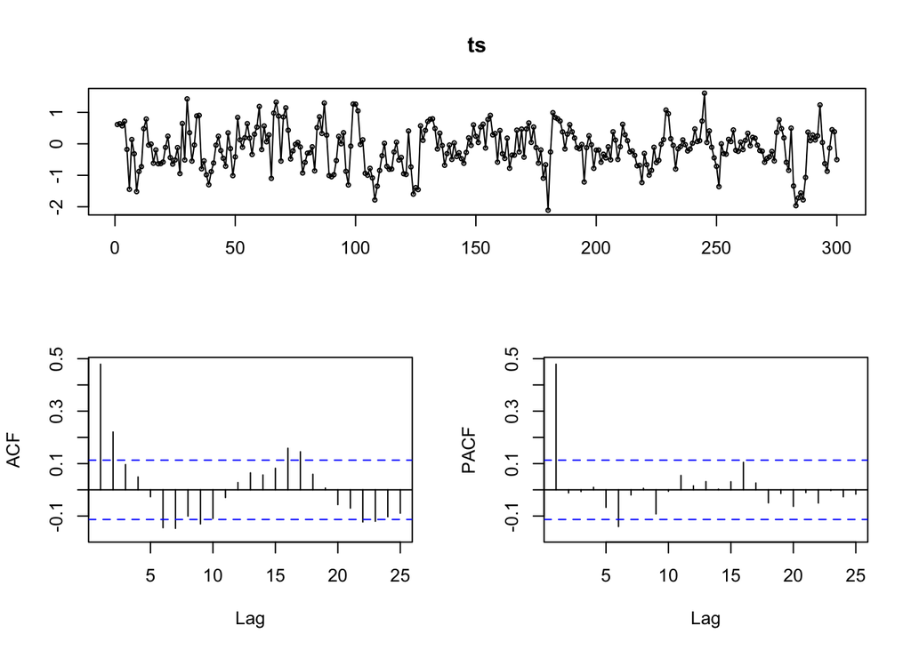

```r
# ACF and PACF
tsdisplay(ts)
```

It shows the series could be $ARMA(1,0,0)$ model. Let’s check the Augmented Dickey-Fuller test.

```r
adf.test(ts) # Augmented Dickey-Fuller
```

```
##
##  Augmented Dickey-Fuller Test
##
## data:  ts
## Dickey-Fuller = -6.9044, Lag order = 6, p-value = 0.01
## alternative hypothesis: stationary
```

Fit $AR(1)$ model on the series data.

```r
fit_ts = arima(ts, order = c(1,0,0))
# check residuals
res.ts = residuals(fit_ts)
```

Perform the McLeod-Li test for conditional heteroscedascity (ARCH).

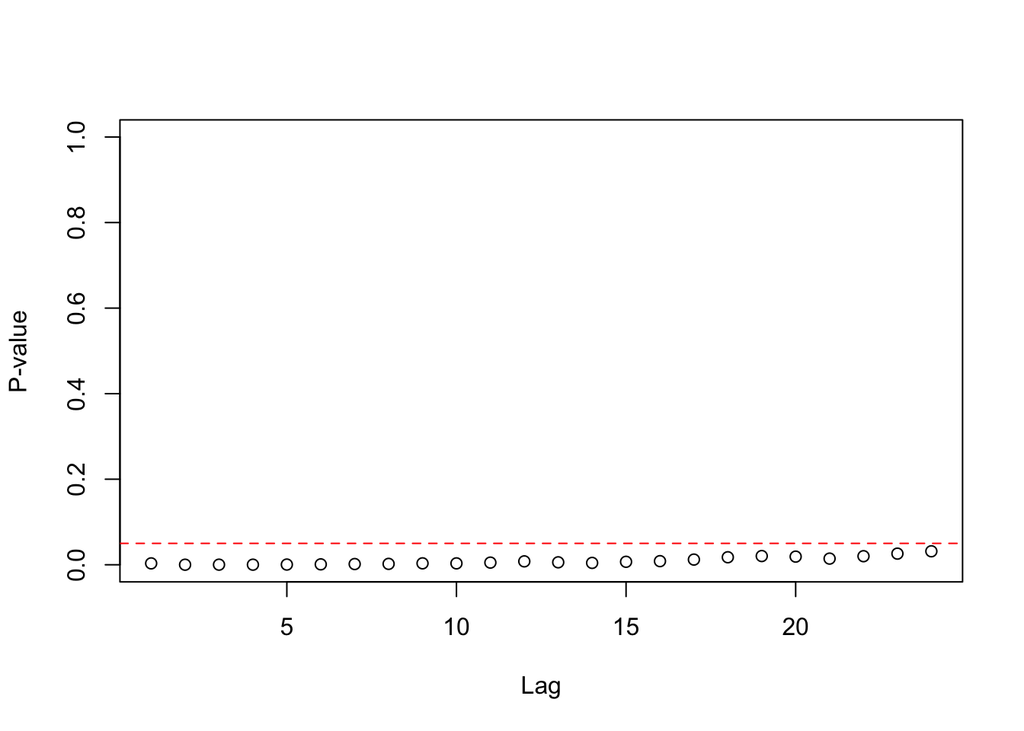

```r
McLeod.Li.test(y = res.ts)
```

For the model residuals, all the lags are significant. This implies the presence of ARCH effect (Autoregressive Conditional Heteroscedastic effect).

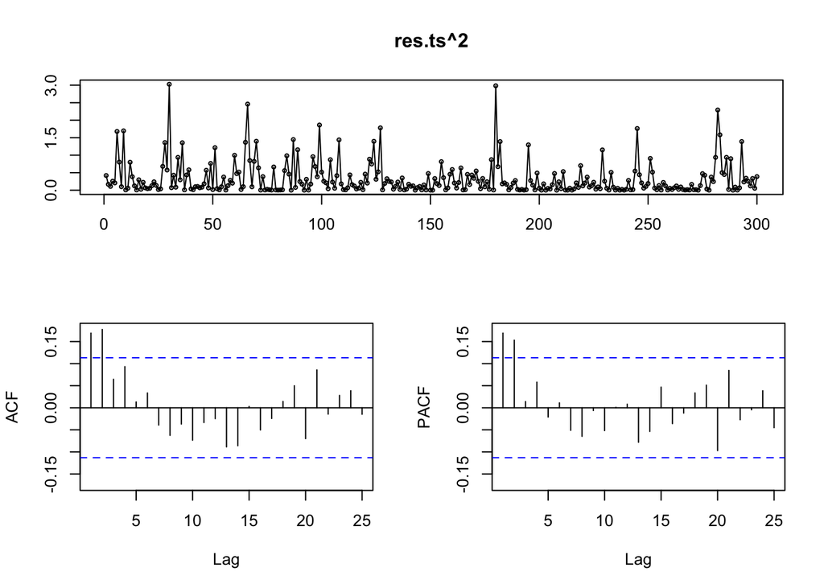

```r
tsdisplay(res.ts^2)
```

```r
fit1 = garchFit(~ arma(1,0) + garch(1,1), include.mean = F)
```

[output not shown]

[output cut: 39 more lines]

[output not shown]

The estimated $\omega$ and $\alpha_1$.

```r
# parameters
fit1@fit$par
```

```
##        ar1      omega     alpha1      beta1
## 0.05152248 0.01126979 0.15835751 0.79882853
```

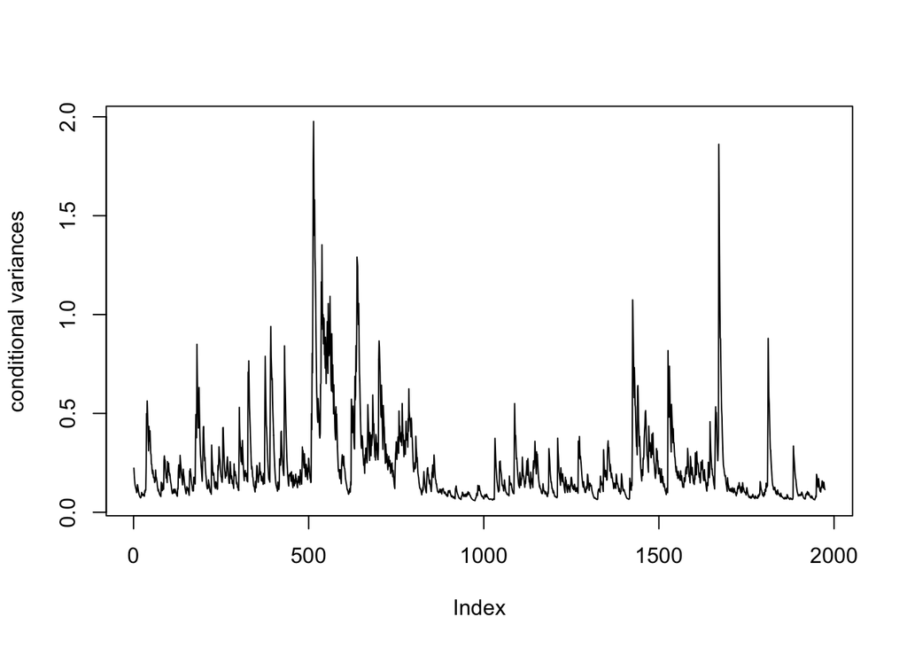

```r
m.11 = garch(res.ts, order = c(1,1), trace=FALSE)
plot(fit1@sigma.t^2, type='l', ylab='conditional variances')
```

Plot ACF:

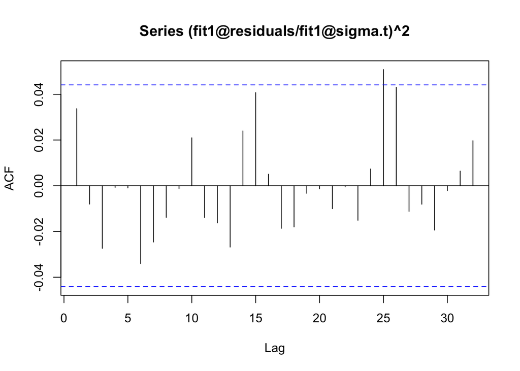

```r
acf((fit1@residuals/fit1@sigma.t)^2)
```

Then we perform Ljung-Box test:

```r
# Ljung-Box test:
Box.test((fit1@residuals/fit1@sigma.t)^2, lag=15, t='Ljung')
```

```
##
##  Box-Ljung test
##
## data:  (fit1@residuals/fit1@sigma.t)^2
## X-squared = 15.399, df = 15, p-value = 0.4231
```

It shows p-value > 0.05, so we fail to reject null hypothesis.

### Simulate Multiple Time Series

```r
K = 20  # simulate 30 time series
multi_series = matrix(NA, K, n)
series_param = matrix(NA, nrow = K, ncol = 6)
colnames(series_param) <- c("u", "phi1", "phi2", "phi3", "autocorrelation", "accepted")
# confidence interval
ci = c(-1.96/sqrt(n), 1.96/sqrt(n))
lags = 20
```

```r
# GARCH(1,1)
spec = garchSpec(model = list(mu = mu, omega = omega, alpha = alpha, beta = beta))
eta = garchSim(spec, n)
```

```r
# multiple time series share the same eta_t part
for(k in 1:K){
  skip_to_next <- FALSE
  # generate u randomly
  u = sample(c(1,2,3), 1, replace = TRUE)
  series_param[k,1] = u

  # the values of AR coefficients (ARIMA)
  phi = 0; if (u > 0) phi = samp_coefs(u)
  series_param[k,2:(u+1)] = phi

  possibleError <- tryCatch({
    # use shared eta to simulate a AR(u) model
    multi_series[k,] = arima.sim(list(ar = phi), n, innov = eta$garch)

    # ACF
    series_ro <- acf(multi_series[k,], lag.max = lags, plot = FALSE)
    series_param[k,5] <- sum(series_ro$acf > ci[1])
    series_param[k,6] <- 1
    },
    error = function(e) {
      e
      print(paste("Skip the non-stationary series in loop ",k,sep = ""))
      })

  if(inherits(possibleError, "error")) next
}
```

```
## [1] "Skip the non-stationary series in loop 2"
## [1] "Skip the non-stationary series in loop 3"
## [1] "Skip the non-stationary series in loop 9"
## [1] "Skip the non-stationary series in loop 12"
## [1] "Skip the non-stationary series in loop 13"
## [1] "Skip the non-stationary series in loop 14"
## [1] "Skip the non-stationary series in loop 15"
## [1] "Skip the non-stationary series in loop 17"
```

```r
# check simulated series data
multi_series[, 1:5]
```

```
##              [,1]        [,2]        [,3]       [,4]        [,5]
##  [1,] -0.20446479  0.12546331  0.11211104  0.3690578 -0.01918362
##  [2,]          NA          NA          NA         NA          NA
##  [3,]          NA          NA          NA         NA          NA
##  [4,]  1.84161145  1.57836516  1.45836658  1.6073956  1.41628973
##  [5,]  1.00245197 -0.77113655  0.78451269 -0.2558575  0.27551667
##  [6,] -2.08863153  0.96331290  2.30519429  0.1290034 -1.99882916
##  [7,]  0.12302387  0.26384364  0.28450138  0.4291205  0.21571338
##  [8,]  0.09419712  0.02030355  0.14039584  0.3381446 -0.06431272
##  [9,]          NA          NA          NA         NA          NA
## [10,] -0.67840239  0.43339015 -0.09287364  0.4432161 -0.18209290
## [11,] -1.61642449  0.36866243  1.35545634  1.1948655  0.17891585
## [12,]          NA          NA          NA         NA          NA
## [13,]          NA          NA          NA         NA          NA
## [14,]          NA          NA          NA         NA          NA
## [15,]          NA          NA          NA         NA          NA
## [16,] -0.36815797 -0.07441510  0.12173141  0.4347431  0.21854597
## [17,]          NA          NA          NA         NA          NA
## [18,] -0.11313353  0.23609483  0.35186631  0.5347380  0.28468820
## [19,] -0.15259072  0.13426624  0.07938687  0.3509309 -0.11528641
## [20,]  0.48885918 -0.14417268  0.20720073  0.3066659 -0.06129728
```

```r
# check series parameters
series_param
```

```
##       u        phi1        phi2        phi3 autocorrelation accepted
##  [1,] 2 -0.23591596  0.03136207          NA              19        1
##  [2,] 2  0.72965236  0.53231920          NA              NA       NA
##  [3,] 3 -0.89783760  0.56218065  0.01441837              NA       NA
##  [4,] 2  0.87930183 -0.04214520          NA              20        1
##  [5,] 1 -0.82526294          NA          NA              15        1
##  [6,] 2  0.26634402 -0.90992564          NA              12        1
##  [7,] 2  0.90611491 -0.83474496          NA              13        1
##  [8,] 1 -0.38054627          NA          NA              19        1
##  [9,] 2  0.07240484  0.99472396          NA              NA       NA
## [10,] 1 -0.55607151          NA          NA              18        1
## [11,] 2  0.74930544 -0.57602028          NA              17        1
## [12,] 3 -0.86106128  0.13841446 -0.08675196              NA       NA
## [13,] 3 -0.16369836 -0.82987699  0.59805228              NA       NA
## [14,] 3 -0.57307342  0.47262598 -0.59297437              NA       NA
## [15,] 2 -0.89824121  0.70328206          NA              NA       NA
## [16,] 1  0.35464400          NA          NA              20        1
## [17,] 3 -0.49080637  0.84896887 -0.57292106              NA       NA
## [18,] 2  0.67295372 -0.39655030          NA              17        1
## [19,] 1 -0.51193367          NA          NA              18        1
## [20,] 1 -0.40977565          NA          NA              19        1
```

Filter out stationary series data that have low autocorrelation.

```r
series_index <- which(series_param[,6] == 1 & !(series_param[,5] > 17 & series_param[,1] == 1))
series_index
```

```
## [1]  1  4  5  6  7 11 18
```

Plot some Time Series as examples.

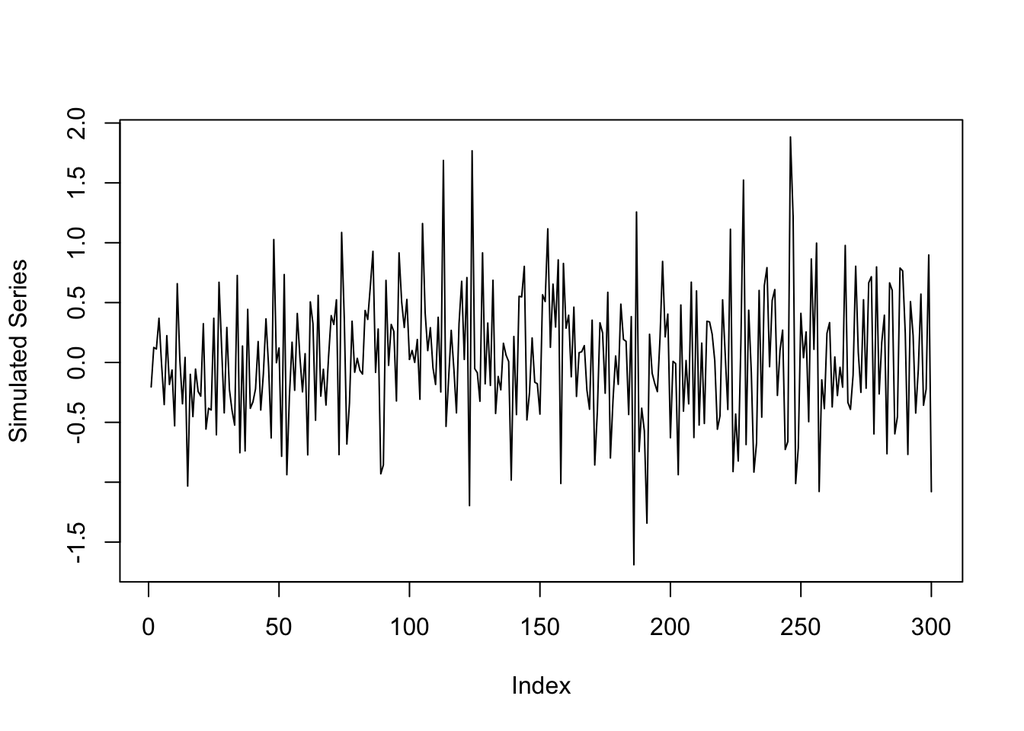

```r
plot(multi_series[series_index[1],], t='l', ylab="Simulated Series")
```

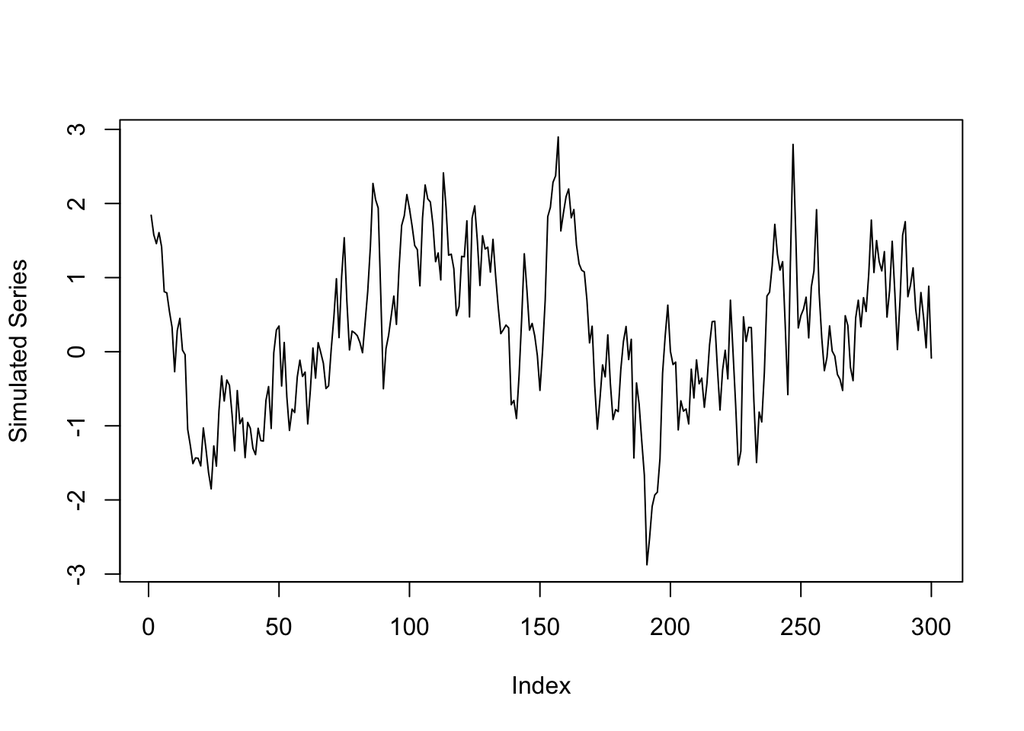

```r
plot(multi_series[series_index[2],], t='l', ylab="Simulated Series")
```

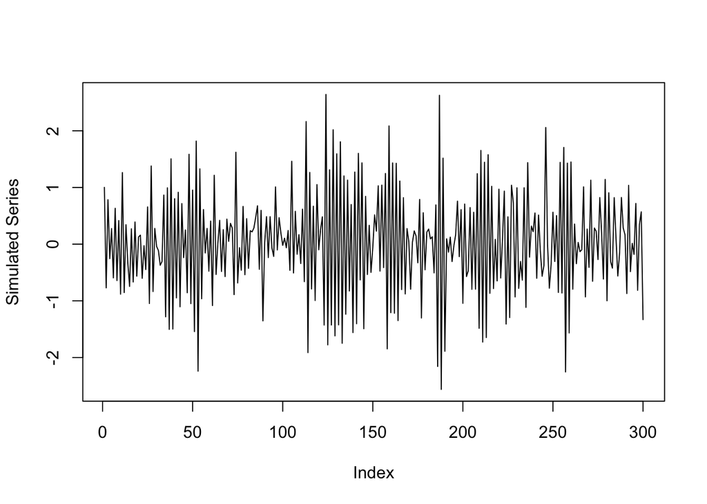

```r
plot(multi_series[series_index[3],], t='l', ylab="Simulated Series")
```

### Identify Single Model

Identify $u$ and $v$ for each series separately. Now select one series as an example to demo.

```r
# K = 20
# find a single series to do demo
index <- 10
tar_ts <- multi_series[index,]
```

```r
# Create a customised function to calculate ACF.
#n <- length(tar_ts)
#lags <- 15
# ACF
# Estimate the sample mean
#y_bar <- mean(tar_ts)

#ro <- rep(NA, lags)
#sum_square <- sum((tar_ts-y_bar)*t(tar_ts-y_bar))

#for(j in (1:lags)){
  # calculate ACF manually
#  y_t <- tail(tar_ts, length(tar_ts) - j)
#  y_tj <- head(tar_ts, length(tar_ts) - j)
#  ro[j] <- sum((y_t - y_bar)*t(y_tj - y_bar))/sum_square
#}
```

Use TSA library to calculate ACF and PACF.

```r
lags <- 15
# ACF
ro <- acf(tar_ts, lag.max = lags, plot = FALSE)
# PACF
phi <- pacf(tar_ts, lag.max = lags, plot = FALSE)
```

Plot ACF and PACF.

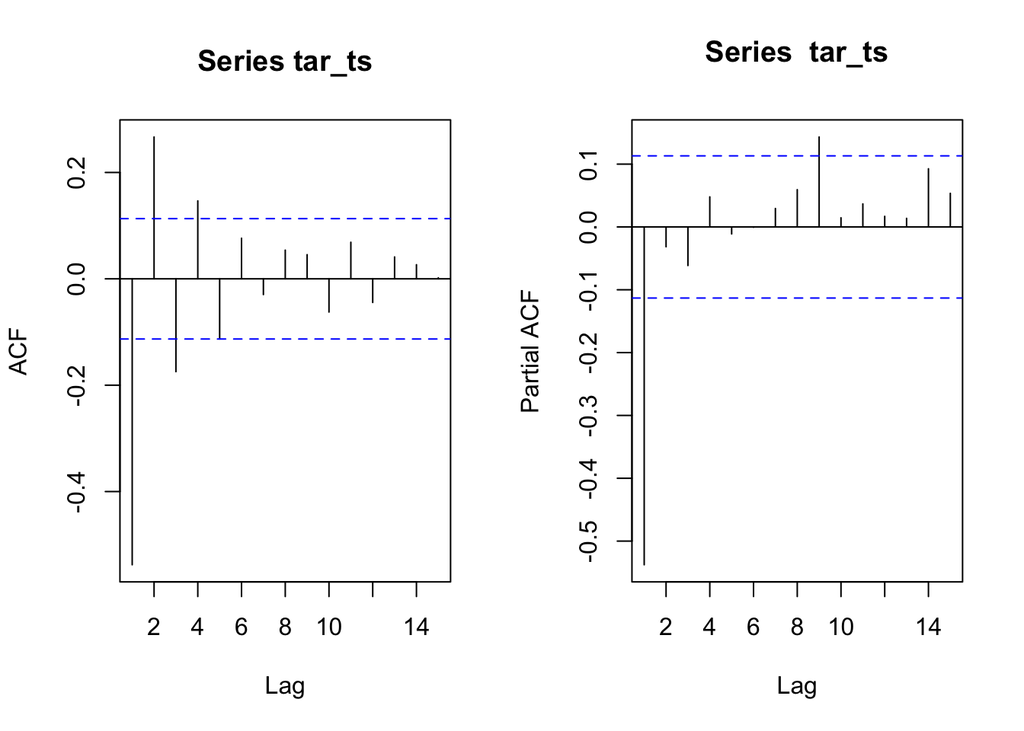

```r
par(mfrow=c(1,2))
acf(tar_ts, lag.max = lags)
pacf(tar_ts, lag.max = lags)
```

Identify the orders of $AR(u)$ components. Create a function to identify the orders.

```r
order_identifier <- function(afc_pacf, lags){
  p_hat <- 1
  q_hat <- 1

  for(l in (2:lags)){
    if(abs(afc_pacf[,'acf'][l]) > ci[2]){
      q_hat = q_hat + 1
    }
    else{
      break
    }
  }

  for(l in (2:lags)){
    if(abs(afc_pacf[,'pacf'][l]) > ci[2]){
      p_hat = p_hat + 1
    }
    else{
      break
    }
  }
  return(list(p_hat = p_hat, q_hat = q_hat))
}
```

```r
#acf_order <- lags - sum(abs(ro$acf) < ci[2])
#pacf_order <- lags - sum(abs(phi$acf) < ci[2])
# the order u is equal to the number of PACF
#u <- pacf_order
```

```r
acf_matrix <- cbind(ro$acf, phi$acf)
colnames(acf_matrix) <- c('acf','pacf')
arma_orders <- order_identifier(acf_matrix, lags)
```

```r
arma_orders$p_hat
```

```
## [1] 1
```

```r
arma_orders$q_hat
```

```
## [1] 4
```

**NOTE:** We have two assumptions: 1. All series have AR component and GARCH component 2. AR component has order less than 4

Fit $AR(u)$ model on the series data.

```r
fit_ts = arima(tar_ts, order = c(arma_orders$p_hat,0,0))
res.ts = residuals(fit_ts)
```

Perform the McLeod-Li test for conditional heteroscedascity (GARCH).

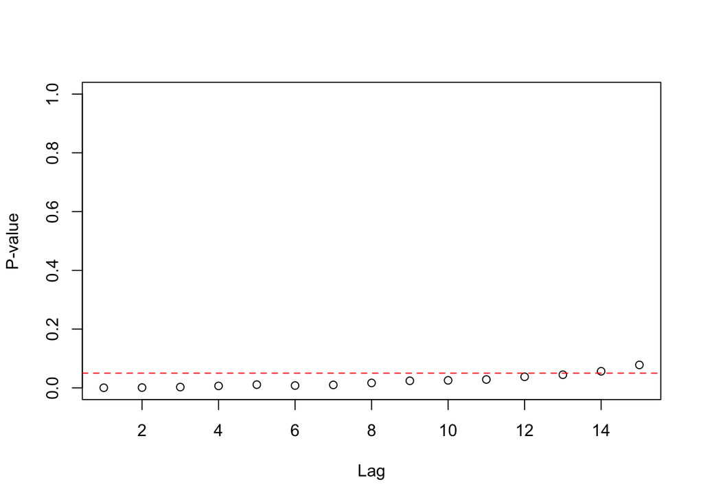

```r
McLeod.Li.test(y = res.ts, gof.lag = lags)
```

```r
ml_test <- McLeod.Li.test(y = res.ts, plot = FALSE, gof.lag = lags)
sum(ml_test$p.values < 0.05)/length(ml_test$p.values)
```

```
## [1] 0.8666667
```

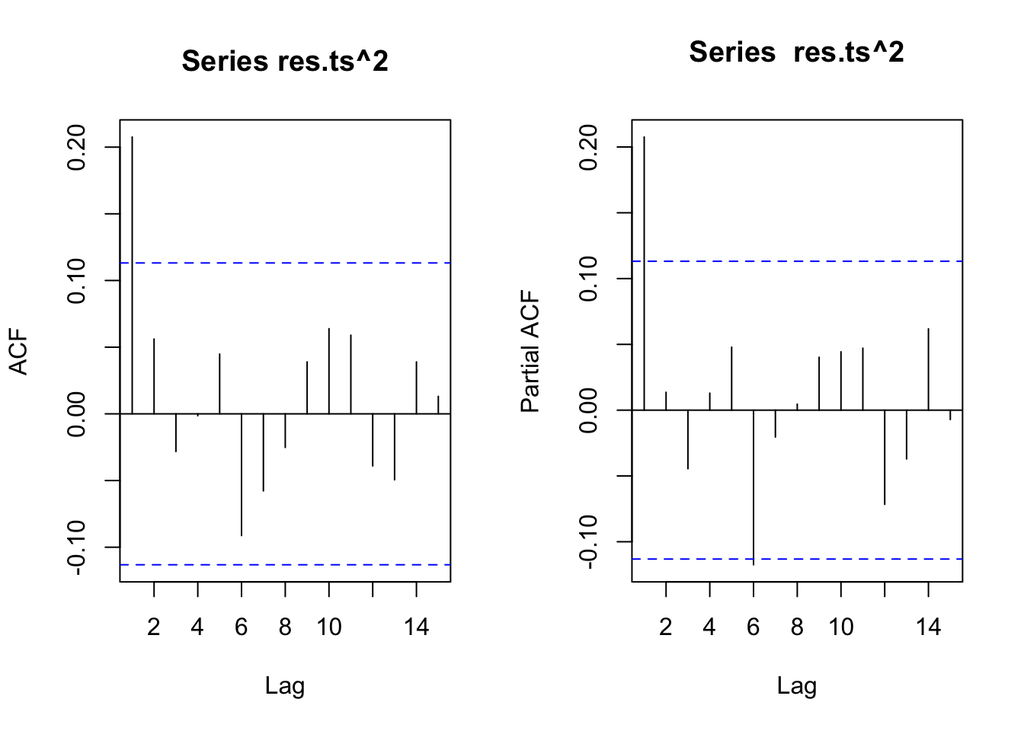

```r
par(mfrow=c(1,2))
acf(res.ts^2, lag.max = 15)
pacf(res.ts^2, lag.max = 15)
```

This shows that the $GARCH(p,q)$ model for the return series implies that the model for the squared returns is an $ARMA(max(p,q),p)$ model. Thus, we can apply the model identification techniques for ARMA models to the squared return series to identify p and $max(p,q)$. In this case, the target series $GARCH$ component is $GARCH(1,1)$.

Create a function to calculate ACF and PACF.

```r
acf_identifier <- function(x, lags){
  # ACF
  ro <- acf(x, lag.max = lags, plot = FALSE)
  # PACF
  phi <- pacf(x, lag.max = lags, plot = FALSE)

  return(cbind(acf = ro$acf, pacf = phi$acf))
}
```

```r
x <- res.ts^2
# ACF and PACF
arch_identify <- acf_identifier(x, lags)

#acf_order <- lags - sum(abs(arch_identify[,'acf']) < ci[2])
#pacf_order <- lags - sum(abs(arch_identify[,'pacf']) < ci[2])

garch_orders <- order_identifier(arch_identify, lags)
garch_orders$p_hat
```

```
## [1] 1
```

```r
garch_orders$q_hat
```

```
## [1] 1
```

```r
fit_res_square <- arima(abs(res.ts), order = c(1,0,1), method = "CSS")
fit_res_square
```

```
##
## Call:
## arima(x = abs(res.ts), order = c(1, 0, 1), method = "CSS")
##
## Coefficients:
##          ar1      ma1  intercept
##       0.2746  -0.0840     0.4314
## s.e.  0.2198   0.2216     0.0231
##
## sigma^2 estimated as 0.1003:  part log likelihood = -80.76
```

```r
# estimated beta
beta_est <- abs(fit_res_square$coef['ma1'])
# estimated alpha
alpha_est <- fit_res_square$coef['ar1'] + fit_res_square$coef['ma1']
# estimated omega
omega_est <- fit_res_square$sigma2

alpha_est
```

```
##       ar1
## 0.1906069
```

```r
beta_est
```

```
##        ma1
## 0.08400868
```

```r
omega_est
```

```
## [1] 0.1003144
```

### Identify Multiple Models

Identify $u$ and $v$ for each series separately. Now select one series as an example to demo.

```r
target_series <- multi_series[series_index,]
N <- nrow(target_series)
lags <- 15
acf_matrix <- matrix(NA, ncol = 2, nrow = lags, dimnames = list(NULL,c('acf','pacf')))
estimate_orders <- matrix(NA, ncol = 2, nrow = N, dimnames = list(NULL,c('p_hat','q_hat')))
residuals_matrix <- matrix(NA, ncol = n, nrow = N)

for(index in (1:N)){
  tar_ts <- target_series[index,]

  # ACF
  ro <- acf(tar_ts, lag.max = lags, plot = FALSE)
  # PACF
  phi <- pacf(tar_ts, lag.max = lags, plot = FALSE)

  acf_matrix[,'acf'] <- as.vector(ro$acf)
  acf_matrix[,'pacf'] <- as.vector(phi$acf)
  arma_orders <- order_identifier(acf_matrix, lags)
  estimate_orders[index,] <- c(arma_orders$p_hat, arma_orders$q_hat)

  # assumption: series has AR component
  fit_ts = arima(tar_ts, order = c(arma_orders$p_hat,0,0))
  x = residuals(fit_ts)
  residuals_matrix[index,] <- x
}
```

Compare actual AR orders and estiamted AR orders:

```r
# actual orders
series_param[series_index,1]
```

```
## [1] 2 2 1 2 2 2 2
```

```r
# estiamted orders
estimate_orders[,1]
```

```
## [1] 1 1 1 2 2 2 2
```

```r
eta_hat <- colMeans(residuals_matrix)
```

```r
x <- eta_hat^2
# ACF and PACF
arch_identify <- acf_identifier(x, lags)
garch_orders_hat <- order_identifier(arch_identify, lags)
garch_orders_hat$p_hat
```

```
## [1] 1
```

```r
garch_orders_hat$q_hat
```

```
## [1] 1
```

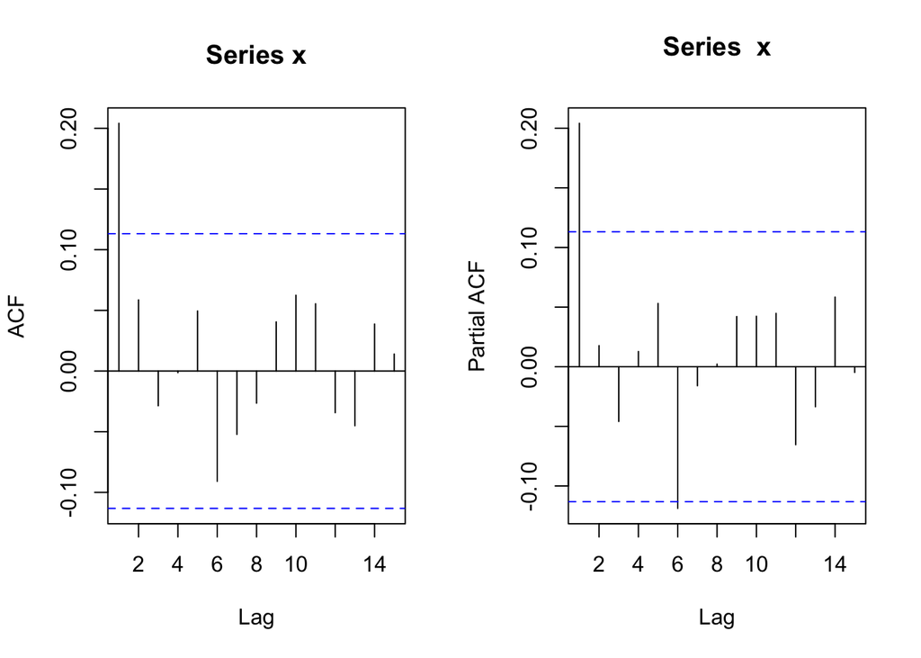

```r
par(mfrow=c(1,2))
acf(x, lag.max = 15)
pacf(x, lag.max = 15)
```

Fit $GARCH(1,1)$

```r
fit_res_square <- arima(x, order = c(1,0,1), method = "ML")
fit_res_square
```

```
##
## Call:
## arima(x = x, order = c(1, 0, 1), method = "ML")
##
## Coefficients:
##          ar1      ma1  intercept
##       0.2661  -0.0639     0.2887
## s.e.  0.2293   0.2353     0.0316
##
## sigma^2 estimated as 0.1849:  log likelihood = -172.52,  aic = 351.04
```

Fit $GARCH(3,3)$

```r
fit_res_square <- arima(x, order = c(3,0,3), method = "ML")
fit_res_square
```

```
##
## Call:
## arima(x = x, order = c(3, 0, 3), method = "ML")
##
## Coefficients:
##           ar1      ar2     ar3     ma1     ma2      ma3  intercept
##       -0.5123  -0.7668  0.2093  0.7273  0.9688  -0.0406     0.2883
## s.e.   0.2986   0.2122  0.2736  0.3038  0.2327   0.3036     0.0313
##
## sigma^2 estimated as 0.1785:  log likelihood = -169.08,  aic = 352.15
```

kaike’s Information Criterion (AIC), which was useful in selecting predictors for regression, is also useful for determining the order of an ARIMA model. Good models are obtained by minimising the AIC. The $GARCH(1,1)$ returns smaller AIC, so it is selected.